# MC Immobilienpreise

## Ausgangslage

Du bist Data Scientist bei einer Firma im Immobilienbereich. Im Rahmen eines Projekts im Sinne der ’Digitalisierung’ sollen Hauspreis-Schätzungen durch ExpertInnen der Firma bis zu einem gewissen Masse für Vorabklärungen automatisiert werden. Dazu soll ein Machine Learning - Modell erstellt werden, das aufgrund von verschiedenen gesammelten Features den Verkaufspreis eines Hauses schätzen soll. Deine Firma plant den Kauf von entsprechenden Daten (Homegate-Daten, Location Scores, ..), möchte aber zuerst an einer einfachen Fallstudie die Chancen und Risiken abschätzen.

Deine Vorgesetzte hat dazu das Melbourne Housing Market - Datenset1 entdeckt und dir ein CSV-File mit Daten übergeben, dass du untersuchen und bearbeiten sollst, um erstens entsprechendes Know-How anzusammeln und zweitens der Firma einen ersten Eindruck vermitteln zu können, welche Aufwände und unvorhergesehene Probleme speziell in der Datenaufbereitung entstehen können und wie genaue Schätzungen hier ungefähr zu erwarten sind. Du freust dich darüber, endlich wieder einmal deine Skills in Data Wrangling und explorativer Datenanalyse zu schärfen, insbesondere weil du mehrere ganze Tage Zeit dafür bekommst.

Das Datenset ist im Trainingscenter verfügbar. Versuche, dich so tief wie möglich in die einzelnen Punkte der Aufgabenstellung einzuarbeiten. Die Auseinandersetzung mit einem komplexen Datenset ist sehr aufwändig, aber essentiell, wenn du dich später erfolgreich mit einer Modellierung auseinandersetzen möchtest. Tust du dies nicht, kannst du relativ einfach an einzelnen Artefakten im Datenset scheitern.

```python
import numpy as np
import pandas as pd
import matplotlib.pyplot as plt
import seaborn as sns
from pandas.plotting import scatter_matrix
```

## 2. Aufgabenstellung

## 2.1 Daten einlesen

```python
data = pd.read_csv('Melbourne_Housing.csv')
data.head()
```

|  | Suburb | Address | Rooms | Type | Price | Method | SellerG | Date | Distance | Postcode | ... | Bathroom | Car | Landsize | BuildingArea | YearBuilt | CouncilArea | Lattitude | Longtitude | Regionname | Propertycount |
| --- | --- | --- | --- | --- | --- | --- | --- | --- | --- | --- | --- | --- | --- | --- | --- | --- | --- | --- | --- | --- | --- |
| 0 | Abbotsford | 68 Studley St | 2 | h | NaN | SS | Jellis | 3/09/2016 | 2.5 | 3067.0 | ... | 1.0 | 1.0 | 126.0 | NaN | NaN | Yarra City Council | -37.8014 | 144.9958 | Northern Metropolitan | 4019.0 |
| 1 | Abbotsford | 85 Turner St | 2 | h | 1480000.0 | S | Biggin | 3/12/2016 | 2.5 | 3067.0 | ... | 1.0 | 1.0 | 202.0 | NaN | NaN | Yarra City Council | -37.7996 | 144.9984 | Northern Metropolitan | 4019.0 |
| 2 | Abbotsford | 25 Bloomburg St | 2 | h | 1035000.0 | S | Biggin | 4/02/2016 | 2.5 | 3067.0 | ... | 1.0 | 0.0 | 156.0 | 79.0 | 1900.0 | Yarra City Council | -37.8079 | 144.9934 | Northern Metropolitan | 4019.0 |
| 3 | Abbotsford | 18/659 Victoria St | 3 | u | NaN | VB | Rounds | 4/02/2016 | 2.5 | 3067.0 | ... | 2.0 | 1.0 | 0.0 | NaN | NaN | Yarra City Council | -37.8114 | 145.0116 | Northern Metropolitan | 4019.0 |
| 4 | Abbotsford | 5 Charles St | 3 | h | 1465000.0 | SP | Biggin | 4/03/2017 | 2.5 | 3067.0 | ... | 2.0 | 0.0 | 134.0 | 150.0 | 1900.0 | Yarra City Council | -37.8093 | 144.9944 | Northern Metropolitan | 4019.0 |

5 rows × 21 columns

Einen Überblick über die Datentypen verschaffen.

```python
data.info()
```

```
<class 'pandas.core.frame.DataFrame'>
RangeIndex: 34857 entries, 0 to 34856
Data columns (total 21 columns):
 #   Column         Non-Null Count  Dtype
---  ------         --------------  -----
 0   Suburb         34857 non-null  object
 1   Address        34857 non-null  object
 2   Rooms          34857 non-null  int64
 3   Type           34857 non-null  object
 4   Price          27247 non-null  float64
 5   Method         34857 non-null  object
 6   SellerG        34857 non-null  object
 7   Date           34857 non-null  object
 8   Distance       34856 non-null  float64
 9   Postcode       34856 non-null  float64
 10  Bedroom2       26640 non-null  float64
 11  Bathroom       26631 non-null  float64
 12  Car            26129 non-null  float64
 13  Landsize       23047 non-null  float64
 14  BuildingArea   13742 non-null  float64
 15  YearBuilt      15551 non-null  float64
 16  CouncilArea    34854 non-null  object
 17  Lattitude      26881 non-null  float64
 18  Longtitude     26881 non-null  float64
 19  Regionname     34854 non-null  object
 20  Propertycount  34854 non-null  float64
dtypes: float64(12), int64(1), object(8)
memory usage: 5.6+ MB
```

## Datenbeschrieb:

**Suburb**: Name des Vorortes → kategorial

**Address**: Adresse → entfernen

**Rooms**: Number of rooms → diskret, ordinal

**Price**: Price in Australian dollars → stetig, verhältniskaliert

**Method**: → kategorial (entfernen)

- S - property sold;
- SP - property sold prior;
- PI - property passed in;
- PN - sold prior not disclosed;
- SN - sold not disclosed;
- NB - no bid;
- VB - vendor bid;
- W - withdrawn prior to auction;
- SA - sold after auction;
- SS - sold after auction price not disclosed.
- N/A - price or highest bid not available.

**Type**: → kategorial

- br - bedroom(s);
- h - house,cottage,villa, semi,terrace;
- u - unit, duplex;
- t - townhouse;
- dev site - development site;
- o res - other residential.

**SellerG**: Real Estate Agent → wird vermutlich nicht benötigt (entfernen)

**Date**: Date sold → Datumsformat

**Distance**: Distance from CBD in Kilometres → stetig

**Regionname**: General Region (West, North West, North, North east … etc.) → entfernen

**Propertycount**: Number of properties that exist in the suburb. → entfernen

**Bedroom2**: Scraped # of Bedrooms (from different source) → diskret, ordinal

**Bathroom**: Number of Bathrooms → diskret, ordinal

**Car**: Number of carspots → diskret, ordinal

**Landsize**: Land Size in Metres → stetig

**BuildingArea**: Building Size in Metres → stetig

**YearBuilt**: Year the house was built → ordinal

**CouncilArea**: Governing council for the area → entfernen

**Lattitude**: Self explanitory → entfernen

**Longtitude**: Self explanitory → entfernen

Entfernen der Spalten, welche nicht für die Modellierung des Hauspreises benötigt werden.

```python
data = data.drop(['Method','SellerG', 'Address', 'CouncilArea', 'Longtitude', 'Lattitude', 'Postcode'], axis=1)
data.head()
```

|  | Suburb | Rooms | Type | Price | Date | Distance | Bedroom2 | Bathroom | Car | Landsize | BuildingArea | YearBuilt | Regionname | Propertycount |
| --- | --- | --- | --- | --- | --- | --- | --- | --- | --- | --- | --- | --- | --- | --- |
| 0 | Abbotsford | 2 | h | NaN | 3/09/2016 | 2.5 | 2.0 | 1.0 | 1.0 | 126.0 | NaN | NaN | Northern Metropolitan | 4019.0 |
| 1 | Abbotsford | 2 | h | 1480000.0 | 3/12/2016 | 2.5 | 2.0 | 1.0 | 1.0 | 202.0 | NaN | NaN | Northern Metropolitan | 4019.0 |
| 2 | Abbotsford | 2 | h | 1035000.0 | 4/02/2016 | 2.5 | 2.0 | 1.0 | 0.0 | 156.0 | 79.0 | 1900.0 | Northern Metropolitan | 4019.0 |
| 3 | Abbotsford | 3 | u | NaN | 4/02/2016 | 2.5 | 3.0 | 2.0 | 1.0 | 0.0 | NaN | NaN | Northern Metropolitan | 4019.0 |
| 4 | Abbotsford | 3 | h | 1465000.0 | 4/03/2017 | 2.5 | 3.0 | 2.0 | 0.0 | 134.0 | 150.0 | 1900.0 | Northern Metropolitan | 4019.0 |

## 2.2 Überblick über die Spalten und Wertebereiche

Um einen Überblick über die Spalten und deren Wertebereiche zu erhalten, werden die Spalten einzeln betrachtet. Dazu kann mit dem Mauszeiger über die Spaltennamen gefahren werden. So werden die wichtigsten Informationen angezeigt. Die einzelnen Spalten werden in der Folge entsprechend bearbeitet, fehlende Werte imputiert oder Datentypen angepasst. Es wird auch jeweils die Verteilung untersucht und wenn nötig Ausreisser entfernt.

```python
data
```

|  | Suburb | Rooms | Type | Price | Date | Distance | Bedroom2 | Bathroom | Car | Landsize | BuildingArea | YearBuilt | Regionname | Propertycount |
| --- | --- | --- | --- | --- | --- | --- | --- | --- | --- | --- | --- | --- | --- | --- |
| 0 | Abbotsford | 2 | h | NaN | 3/09/2016 | 2.5 | 2.0 | 1.0 | 1.0 | 126.0 | NaN | NaN | Northern Metropolitan | 4019.0 |
| 1 | Abbotsford | 2 | h | 1480000.0 | 3/12/2016 | 2.5 | 2.0 | 1.0 | 1.0 | 202.0 | NaN | NaN | Northern Metropolitan | 4019.0 |
| 2 | Abbotsford | 2 | h | 1035000.0 | 4/02/2016 | 2.5 | 2.0 | 1.0 | 0.0 | 156.0 | 79.0 | 1900.0 | Northern Metropolitan | 4019.0 |
| 3 | Abbotsford | 3 | u | NaN | 4/02/2016 | 2.5 | 3.0 | 2.0 | 1.0 | 0.0 | NaN | NaN | Northern Metropolitan | 4019.0 |
| 4 | Abbotsford | 3 | h | 1465000.0 | 4/03/2017 | 2.5 | 3.0 | 2.0 | 0.0 | 134.0 | 150.0 | 1900.0 | Northern Metropolitan | 4019.0 |
| ... | ... | ... | ... | ... | ... | ... | ... | ... | ... | ... | ... | ... | ... | ... |
| 34852 | Yarraville | 4 | h | 1480000.0 | 24/02/2018 | 6.3 | 4.0 | 1.0 | 3.0 | 593.0 | NaN | NaN | Western Metropolitan | 6543.0 |
| 34853 | Yarraville | 2 | h | 888000.0 | 24/02/2018 | 6.3 | 2.0 | 2.0 | 1.0 | 98.0 | 104.0 | 2018.0 | Western Metropolitan | 6543.0 |
| 34854 | Yarraville | 2 | t | 705000.0 | 24/02/2018 | 6.3 | 2.0 | 1.0 | 2.0 | 220.0 | 120.0 | 2000.0 | Western Metropolitan | 6543.0 |
| 34855 | Yarraville | 3 | h | 1140000.0 | 24/02/2018 | 6.3 | NaN | NaN | NaN | NaN | NaN | NaN | Western Metropolitan | 6543.0 |
| 34856 | Yarraville | 2 | h | 1020000.0 | 24/02/2018 | 6.3 | 2.0 | 1.0 | 0.0 | 250.0 | 103.0 | 1930.0 | Western Metropolitan | 6543.0 |

34857 rows × 14 columns

### Suburb, Regionname, Propertycount

Die Variable Suburb weist keine fehlenden Werte auf, hingegen Regionname und Propertycount schon. Daher wird von diesen drei Spalten (welche alle eine ähnliche Aussage haben) nur die Spalte Suburb behalten. Die Spalte wird in eine kategoriale Variable umgewandelt.

```python
data_reduced = data.copy()
data_reduced = data_reduced.drop(['Regionname', 'Propertycount'], axis=1)
data_reduced['Suburb']= pd.Categorical(data_reduced['Suburb'])
```

### Rooms

```python
data_reduced['Rooms'] = data_reduced['Rooms'].apply(lambda x: np.where(x > 5, np.nan, x)).dropna()
data_reduced
```

|  | Suburb | Rooms | Type | Price | Date | Distance | Bedroom2 | Bathroom | Car | Landsize | BuildingArea | YearBuilt |
| --- | --- | --- | --- | --- | --- | --- | --- | --- | --- | --- | --- | --- |
| 0 | Abbotsford | 2.0 | h | NaN | 3/09/2016 | 2.5 | 2.0 | 1.0 | 1.0 | 126.0 | NaN | NaN |
| 1 | Abbotsford | 2.0 | h | 1480000.0 | 3/12/2016 | 2.5 | 2.0 | 1.0 | 1.0 | 202.0 | NaN | NaN |
| 2 | Abbotsford | 2.0 | h | 1035000.0 | 4/02/2016 | 2.5 | 2.0 | 1.0 | 0.0 | 156.0 | 79.0 | 1900.0 |
| 3 | Abbotsford | 3.0 | u | NaN | 4/02/2016 | 2.5 | 3.0 | 2.0 | 1.0 | 0.0 | NaN | NaN |
| 4 | Abbotsford | 3.0 | h | 1465000.0 | 4/03/2017 | 2.5 | 3.0 | 2.0 | 0.0 | 134.0 | 150.0 | 1900.0 |
| ... | ... | ... | ... | ... | ... | ... | ... | ... | ... | ... | ... | ... |
| 34852 | Yarraville | 4.0 | h | 1480000.0 | 24/02/2018 | 6.3 | 4.0 | 1.0 | 3.0 | 593.0 | NaN | NaN |
| 34853 | Yarraville | 2.0 | h | 888000.0 | 24/02/2018 | 6.3 | 2.0 | 2.0 | 1.0 | 98.0 | 104.0 | 2018.0 |
| 34854 | Yarraville | 2.0 | t | 705000.0 | 24/02/2018 | 6.3 | 2.0 | 1.0 | 2.0 | 220.0 | 120.0 | 2000.0 |
| 34855 | Yarraville | 3.0 | h | 1140000.0 | 24/02/2018 | 6.3 | NaN | NaN | NaN | NaN | NaN | NaN |
| 34856 | Yarraville | 2.0 | h | 1020000.0 | 24/02/2018 | 6.3 | 2.0 | 1.0 | 0.0 | 250.0 | 103.0 | 1930.0 |

34857 rows × 12 columns

Die Verteilung der Werte wird mit einem Histogramm dargestellt.

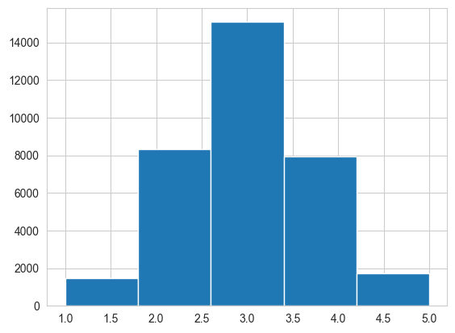

```python
data_reduced['Rooms'].hist(bins=5)
```

### Type

Type weist 3 verschiedene Typen auf und keine fehlenden Werte. Der Datentyp wird in eine kategoriale Variable umgewandelt und anschliessend die Verteilung der Werte dargestellt.

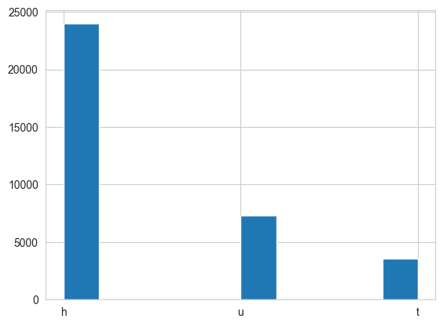

```python
data_reduced['Type']= pd.Categorical(data_reduced['Type'])
data_reduced['Type'].hist()
```

### Price

Price ist für die Modellierung die abhängige Variable und unerlässlich. Daher wird versucht, die fehlenden Werte mit der Methode des k-Nearest Neighbors (kNN) zu ersetzen. Dazu wird KNNImputer aus sklearn.impute verwendet. Der Vorteil einer solchen Imputation ist, dass wir dadurch keine Observationen verlieren. Der Nachteil ist, dass wir dadurch den Datensatz verfälschen könnten.

```python
imputed_price_knn = data_reduced.copy()
imputed_price_knn = imputed_price_knn.drop(['Suburb', 'Date', 'Type'], axis=1)
from sklearn.impute import KNNImputer
imputer = KNNImputer(n_neighbors=3)
imputed_price_knn = pd.DataFrame(imputer.fit_transform(imputed_price_knn), columns = imputed_price_knn.columns)
imputed_price_knn
```

|  | Rooms | Price | Distance | Bedroom2 | Bathroom | Car | Landsize | BuildingArea | YearBuilt |
| --- | --- | --- | --- | --- | --- | --- | --- | --- | --- |
| 0 | 2.0 | 6.823333e+05 | 2.5 | 2.000000 | 1.000000 | 1.000000 | 126.0 | 83.666667 | 2004.000000 |
| 1 | 2.0 | 1.480000e+06 | 2.5 | 2.000000 | 1.000000 | 1.000000 | 202.0 | 111.333333 | 1946.666667 |
| 2 | 2.0 | 1.035000e+06 | 2.5 | 2.000000 | 1.000000 | 0.000000 | 156.0 | 79.000000 | 1900.000000 |
| 3 | 3.0 | 9.630000e+05 | 2.5 | 3.000000 | 2.000000 | 1.000000 | 0.0 | 116.333333 | 1998.333333 |
| 4 | 3.0 | 1.465000e+06 | 2.5 | 3.000000 | 2.000000 | 0.000000 | 134.0 | 150.000000 | 1900.000000 |
| ... | ... | ... | ... | ... | ... | ... | ... | ... | ... |
| 34852 | 4.0 | 1.480000e+06 | 6.3 | 4.000000 | 1.000000 | 3.000000 | 593.0 | 158.666667 | 1940.000000 |
| 34853 | 2.0 | 8.880000e+05 | 6.3 | 2.000000 | 2.000000 | 1.000000 | 98.0 | 104.000000 | 2018.000000 |
| 34854 | 2.0 | 7.050000e+05 | 6.3 | 2.000000 | 1.000000 | 2.000000 | 220.0 | 120.000000 | 2000.000000 |
| 34855 | 3.0 | 1.140000e+06 | 6.3 | 2.333333 | 1.666667 | 1.333333 | 356.0 | 176.666667 | 1930.000000 |
| 34856 | 2.0 | 1.020000e+06 | 6.3 | 2.000000 | 1.000000 | 0.000000 | 250.0 | 103.000000 | 1930.000000 |

34857 rows × 9 columns

Die zuvor entfernten Spalten werden wieder hinzugefügt.

```python
data_reduced_knn = pd.concat([data_reduced[['Suburb', 'Date', 'Type']], imputed_price_knn], axis=1)
data_reduced_knn[['Price', 'Landsize', 'BuildingArea', 'Bedroom2', 'Bathroom', 'Car', 'YearBuilt']] = data_reduced_knn[['Price', 'Landsize', 'BuildingArea', 'Bedroom2', 'Bathroom', 'Car', 'YearBuilt']].round(0)
data_reduced_knn
```

|  | Suburb | Date | Type | Rooms | Price | Distance | Bedroom2 | Bathroom | Car | Landsize | BuildingArea | YearBuilt |
| --- | --- | --- | --- | --- | --- | --- | --- | --- | --- | --- | --- | --- |
| 0 | Abbotsford | 3/09/2016 | h | 2.0 | 682333.0 | 2.5 | 2.0 | 1.0 | 1.0 | 126.0 | 84.0 | 2004.0 |
| 1 | Abbotsford | 3/12/2016 | h | 2.0 | 1480000.0 | 2.5 | 2.0 | 1.0 | 1.0 | 202.0 | 111.0 | 1947.0 |
| 2 | Abbotsford | 4/02/2016 | h | 2.0 | 1035000.0 | 2.5 | 2.0 | 1.0 | 0.0 | 156.0 | 79.0 | 1900.0 |
| 3 | Abbotsford | 4/02/2016 | u | 3.0 | 963000.0 | 2.5 | 3.0 | 2.0 | 1.0 | 0.0 | 116.0 | 1998.0 |
| 4 | Abbotsford | 4/03/2017 | h | 3.0 | 1465000.0 | 2.5 | 3.0 | 2.0 | 0.0 | 134.0 | 150.0 | 1900.0 |
| ... | ... | ... | ... | ... | ... | ... | ... | ... | ... | ... | ... | ... |
| 34852 | Yarraville | 24/02/2018 | h | 4.0 | 1480000.0 | 6.3 | 4.0 | 1.0 | 3.0 | 593.0 | 159.0 | 1940.0 |
| 34853 | Yarraville | 24/02/2018 | h | 2.0 | 888000.0 | 6.3 | 2.0 | 2.0 | 1.0 | 98.0 | 104.0 | 2018.0 |
| 34854 | Yarraville | 24/02/2018 | t | 2.0 | 705000.0 | 6.3 | 2.0 | 1.0 | 2.0 | 220.0 | 120.0 | 2000.0 |
| 34855 | Yarraville | 24/02/2018 | h | 3.0 | 1140000.0 | 6.3 | 2.0 | 2.0 | 1.0 | 356.0 | 177.0 | 1930.0 |
| 34856 | Yarraville | 24/02/2018 | h | 2.0 | 1020000.0 | 6.3 | 2.0 | 1.0 | 0.0 | 250.0 | 103.0 | 1930.0 |

34857 rows × 12 columns

Nun schauen wir uns die Verteilung des Preises genauer an.

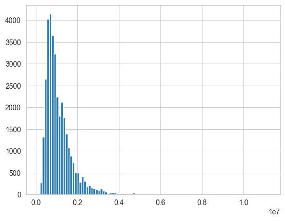

```python
data_reduced_knn['Price'].hist(bins=100)
```

Um die Verteilung besser darzustellen, werden die Ausreisser entfernt. Dies wird mit der IQR-Methode gemacht, da die Verteilung nicht normalverteilt ist.

```python
q1 = data_reduced_knn['Price'].quantile(0.25)
q3 = data_reduced_knn['Price'].quantile(0.75)
iqr = q3 - q1
data_reduced_knn = data_reduced_knn[(data_reduced_knn['Price'] > (q1 - 1.5 * iqr)) & (data_reduced_knn['Price'] < (q3 + 1.5 * iqr))]
```

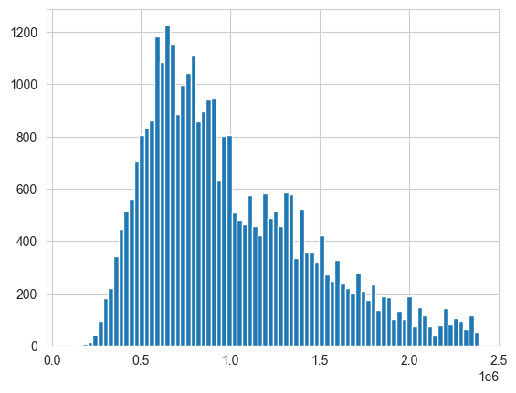

```python
data_reduced_knn['Price'].hist(bins=80)
```

Die Verteilung ist nun besser ersichtlich. Die Verteilung ist nicht normalverteilt, sondern eher rechtsschief. Dies ist auch logisch, da es nur wenige sehr teure Objekte gibt. Die meisten Objekte sind im unteren bis mittleren Preissegment. Die Variable wird noch in einem Boxplot dargestellt.

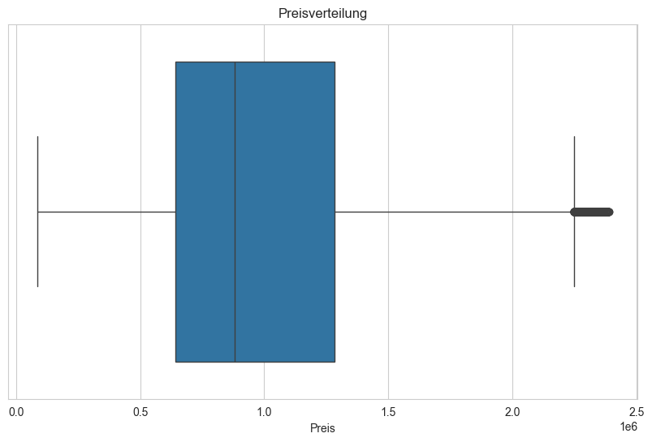

```python
plt.figure(figsize=(10, 6))
sns.boxplot(x='Price', data=data_reduced_knn)
plt.xlabel('Preis')
plt.title('Preisverteilung')
plt.show()
```

### Date

Date weist keine fehlenden Werte auf. Der Datentyp wird in ein Datumsformat umgewandelt.

```python
data_reduced_knn.loc[data_reduced_knn.index, 'Date'] = pd.to_datetime(data_reduced_knn['Date'], format='%d/%m/%Y')
```

### Distance

Distance weist durch die Imputation keinen fehlenden Wert mehr auf. Die 0-Werte werden genauer untersucht.

```python
distance_zero = data_reduced_knn[data_reduced_knn['Distance'] == 0]
distance_zero
```

|  | Suburb | Date | Type | Rooms | Price | Distance | Bedroom2 | Bathroom | Car | Landsize | BuildingArea | YearBuilt |
| --- | --- | --- | --- | --- | --- | --- | --- | --- | --- | --- | --- | --- |
| 15114 | Melbourne | 2017-06-03 00:00:00 | u | 2.0 | 803333.0 | 0.0 | 2.0 | 1.0 | 1.0 | 0.0 | 83.0 | 1995.0 |
| 15115 | Melbourne | 2017-06-03 00:00:00 | u | 2.0 | 850000.0 | 0.0 | 2.0 | 2.0 | 1.0 | 897.0 | 72.0 | 2006.0 |
| 15774 | Melbourne | 2017-06-17 00:00:00 | u | 2.0 | 740000.0 | 0.0 | 2.0 | 1.0 | 1.0 | 0.0 | 113.0 | 1999.0 |
| 15775 | Melbourne | 2017-06-17 00:00:00 | u | 1.0 | 510000.0 | 0.0 | 1.0 | 1.0 | 1.0 | 1314.0 | 77.0 | 2007.0 |
| 15776 | Melbourne | 2017-06-17 00:00:00 | u | 2.0 | 820000.0 | 0.0 | 2.0 | 2.0 | 1.0 | 897.0 | 72.0 | 2006.0 |
| ... | ... | ... | ... | ... | ... | ... | ... | ... | ... | ... | ... | ... |
| 33516 | Melbourne | 2018-03-17 00:00:00 | u | 1.0 | 415000.0 | 0.0 | 2.0 | 1.0 | 1.0 | 0.0 | 47.0 | 2010.0 |
| 33517 | Melbourne | 2018-03-17 00:00:00 | u | 2.0 | 1260000.0 | 0.0 | 2.0 | 2.0 | 1.0 | 897.0 | 72.0 | 2006.0 |
| 33518 | Melbourne | 2018-03-17 00:00:00 | u | 2.0 | 650000.0 | 0.0 | 2.0 | 2.0 | 1.0 | 897.0 | 86.0 | 2006.0 |
| 34471 | Melbourne | 2018-02-24 00:00:00 | u | 2.0 | 803333.0 | 0.0 | 2.0 | 1.0 | 1.0 | 0.0 | 83.0 | 1995.0 |
| 34472 | Melbourne | 2018-02-24 00:00:00 | u | 2.0 | 780000.0 | 0.0 | 2.0 | 2.0 | 1.0 | 897.0 | 72.0 | 2006.0 |

76 rows × 12 columns

Die Werte mit O in Distance sind in Meldbourne selbst. Nun wird noch überprüft, ob Werte in Melbourne bei Distance alle 0 eingetragen haben.

```python
melbourne_zero = data_reduced_knn[data_reduced_knn['Suburb'] == 'Melbourne']
melbourne_zero
```

|  | Suburb | Date | Type | Rooms | Price | Distance | Bedroom2 | Bathroom | Car | Landsize | BuildingArea | YearBuilt |
| --- | --- | --- | --- | --- | --- | --- | --- | --- | --- | --- | --- | --- |
| 6640 | Melbourne | 2016-09-03 00:00:00 | u | 1.0 | 378333.0 | 2.8 | 1.0 | 1.0 | 1.0 | 0.0 | 53.0 | 1900.0 |
| 6641 | Melbourne | 2016-09-03 00:00:00 | u | 1.0 | 400000.0 | 2.8 | 1.0 | 1.0 | 1.0 | 315.0 | 50.0 | 1945.0 |
| 6642 | Melbourne | 2016-12-03 00:00:00 | u | 1.0 | 365000.0 | 2.8 | 1.0 | 1.0 | 1.0 | 315.0 | 50.0 | 1945.0 |
| 6643 | Melbourne | 2016-12-03 00:00:00 | u | 1.0 | 427000.0 | 2.8 | 1.0 | 1.0 | 0.0 | 0.0 | 48.0 | 1956.0 |
| 6644 | Melbourne | 2016-12-03 00:00:00 | u | 2.0 | 1200000.0 | 2.8 | 2.0 | 1.0 | 1.0 | 0.0 | 61.0 | 2010.0 |
| ... | ... | ... | ... | ... | ... | ... | ... | ... | ... | ... | ... | ... |
| 33516 | Melbourne | 2018-03-17 00:00:00 | u | 1.0 | 415000.0 | 0.0 | 2.0 | 1.0 | 1.0 | 0.0 | 47.0 | 2010.0 |
| 33517 | Melbourne | 2018-03-17 00:00:00 | u | 2.0 | 1260000.0 | 0.0 | 2.0 | 2.0 | 1.0 | 897.0 | 72.0 | 2006.0 |
| 33518 | Melbourne | 2018-03-17 00:00:00 | u | 2.0 | 650000.0 | 0.0 | 2.0 | 2.0 | 1.0 | 897.0 | 86.0 | 2006.0 |
| 34471 | Melbourne | 2018-02-24 00:00:00 | u | 2.0 | 803333.0 | 0.0 | 2.0 | 1.0 | 1.0 | 0.0 | 83.0 | 1995.0 |
| 34472 | Melbourne | 2018-02-24 00:00:00 | u | 2.0 | 780000.0 | 0.0 | 2.0 | 2.0 | 1.0 | 897.0 | 72.0 | 2006.0 |

201 rows × 12 columns

Es gibt Werte in Melbourne, welche bis 2.8 gehen. Die Werte werden so belassen, da es sich vermutlich bei den 0-Werten um die Innenstadt handelt und die weiteren Werte die Distanz zur Innenstadt angeben.

### Bedroom2, Bathroom, Car

Die fehlenden Werte in Bedroom2, Bathroom, und Car wurden auch mit der KNN-Methode ersetzt. Die Werte mit 0 in Bedroom2 und Bathroom werden in NaN umgewandelt, da es keine Liegenschaften ohne Badezimmer/Schlafzimmer gibt. Die 0-Werte in Car werden so belassen, da es durchaus Liegenschaften ohne Parkplatz gibt.

```python
data_reduced_knn.loc[data_reduced_knn.index,['Bedroom2', 'Bathroom']] = data_reduced_knn[['Bedroom2', 'Bathroom']].replace(0, np.nan)
```

Die Verteilung der Werte in Bedroom2 wird genauer angeschaut.

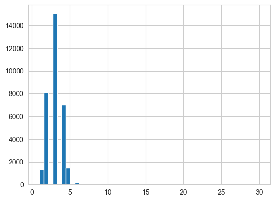

```python
data_reduced_knn['Bedroom2'].hist(bins=50)
```

Es fällt auf, dass ab 6 Schlafzimmern nicht mehr viele Daten vorhanden sind. Deshalb werden diese Werte aus dem Datensatz entfernt.

```python
data_reduced_knn.loc[data_reduced_knn.index, 'Bedroom2'] = data_reduced_knn['Bedroom2'].apply(lambda x: np.where(x > 5, np.nan, x)).dropna()
```

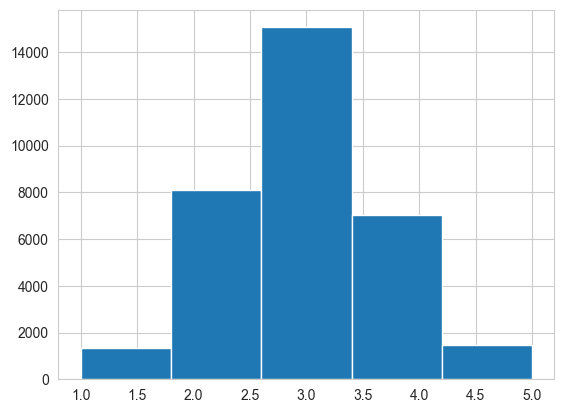

```python
data_reduced_knn['Bedroom2'].hist(bins=5)
```

Nun sieht die Verteilung besser aus. Weiter schauen wir uns die Verteilung der Badezimmer an.

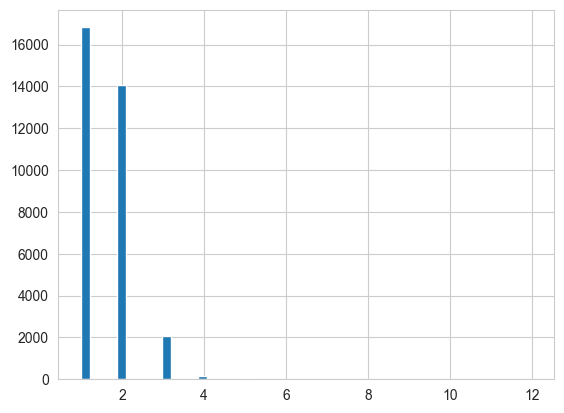

```python
data_reduced_knn['Bathroom'].hist(bins=50)
```

Auch hier hat es wenige Daten mit mehr als 3 Badezimmern. Es werden deshalb alle Werte über 3 entfernt.

```python
data_reduced_knn.loc[data_reduced_knn.index, 'Bathroom'] = data_reduced_knn['Bathroom'].apply(lambda x: np.where(x > 3, np.nan, x)).dropna()
```

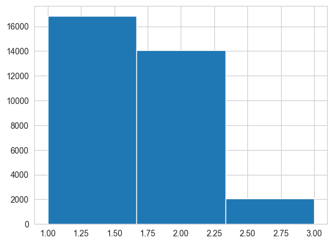

```python
data_reduced_knn['Bathroom'].hist(bins=3)
```

Die Verteilung der Parkplätze wird ebenfalls angeschaut.

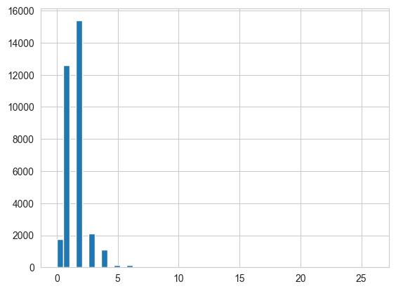

```python
data_reduced_knn['Car'].hist(bins=50)
```

Objekte mit mehr als 4 Parkplätzen werden entfernt, da diese Observationen ein Modell mehr verwirren könnten als dass sie nützen.

```python
data_reduced_knn.loc[data_reduced_knn.index, 'Car'] = data_reduced_knn['Car'].apply(lambda x: np.where(x > 4, np.nan, x)).dropna()
```

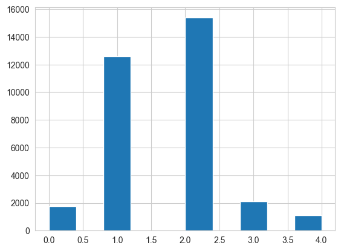

```python
data_reduced_knn['Car'].hist(bins=10)
```

### Landsize, BuildingArea

Die 0-Werte in Landsize und BuildingArea können so auch nicht sein und werden in NaN umgewandelt. Die Observationen werden aber nicht gelöscht, da die restlichen Werte erhalten werden sollen.

```python
data_reduced_knn.loc[data_reduced_knn.index, ['Landsize', 'BuildingArea']] = data_reduced_knn[['Landsize', 'BuildingArea']].replace(0, np.nan)
```

### YearBuilt

YearBuilt weist beim Maximal- bzw. Minimalwert jeweils Fehler auf. Alle Werte über 2023 sowie unter 1803 (erste Erkundung von Melbourne) werden durch NaN ersetzt.

```python
data_reduced_knn.loc[data_reduced_knn.index, 'YearBuilt'] = data_reduced_knn['YearBuilt'].apply(lambda x: np.where(x > 2023, np.nan, x))
data_reduced_knn.loc[data_reduced_knn.index,'YearBuilt'] = data_reduced_knn['YearBuilt'].apply(lambda x: np.where(x < 1803, np.nan, x))
data_reduced_knn['YearBuilt'].describe()
```

```
count    33251.000000
mean      1966.876335
std         30.573082
min       1820.000000
25%       1950.000000
50%       1970.000000
75%       1990.000000
max       2019.000000
Name: YearBuilt, dtype: float64
```

### Aufbereiteter Datensatz

Nach der Bearbeitung der einzelnen Spalten wird der Datensatz nochmals angeschaut.

```python
data_reduced_knn.info()
```

```
<class 'pandas.core.frame.DataFrame'>
Index: 33257 entries, 0 to 34856
Data columns (total 12 columns):
 #   Column        Non-Null Count  Dtype
---  ------        --------------  -----
 0   Suburb        33257 non-null  category
 1   Date          33257 non-null  object
 2   Type          33257 non-null  category
 3   Rooms         33257 non-null  float64
 4   Price         33257 non-null  float64
 5   Distance      33257 non-null  float64
 6   Bedroom2      33004 non-null  float64
 7   Bathroom      32976 non-null  float64
 8   Car           32932 non-null  float64
 9   Landsize      30492 non-null  float64
 10  BuildingArea  33186 non-null  float64
 11  YearBuilt     33251 non-null  float64
dtypes: category(2), float64(9), object(1)
memory usage: 3.9+ MB
```

```python
data_reduced_knn.describe()
```

|  | Rooms | Price | Distance | Bedroom2 | Bathroom | Car | Landsize | BuildingArea | YearBuilt |
| --- | --- | --- | --- | --- | --- | --- | --- | --- | --- |
| count | 33257.000000 | 3.325700e+04 | 33257.000000 | 33004.000000 | 32976.000000 | 32932.000000 | 30492.000000 | 33186.000000 | 33251.000000 |
| mean | 2.954827 | 9.927354e+05 | 11.354855 | 2.975064 | 1.553190 | 1.643174 | 639.477830 | 149.443862 | 1966.876335 |
| std | 0.893540 | 4.586037e+05 | 6.866711 | 0.894395 | 0.611507 | 0.815453 | 1934.294432 | 264.734511 | 30.573082 |
| min | 1.000000 | 8.500000e+04 | 0.000000 | 1.000000 | 1.000000 | 0.000000 | 1.000000 | 1.000000 | 1820.000000 |
| 25% | 2.000000 | 6.416670e+05 | 6.400000 | 2.000000 | 1.000000 | 1.000000 | 307.000000 | 101.000000 | 1950.000000 |
| 50% | 3.000000 | 8.800000e+05 | 10.500000 | 3.000000 | 1.000000 | 2.000000 | 538.000000 | 133.000000 | 1970.000000 |
| 75% | 4.000000 | 1.285000e+06 | 14.200000 | 4.000000 | 2.000000 | 2.000000 | 671.000000 | 178.000000 | 1990.000000 |
| max | 5.000000 | 2.390000e+06 | 48.100000 | 5.000000 | 3.000000 | 4.000000 | 146699.000000 | 44515.000000 | 2019.000000 |

Nochmals einen Überblick über die fehlenden Werte.

```python
data_reduced_knn.isnull().sum()
```

```
Suburb             0
Date               0
Type               0
Rooms              0
Price              0
Distance           0
Bedroom2         253
Bathroom         281
Car              325
Landsize        2765
BuildingArea      71
YearBuilt          6
dtype: int64
```

Nun noch eine Zusammenfassung der Höchstwerte im Datensatz.

```python
# höchstwerte der Spalten
data_num = data_reduced_knn.select_dtypes(include=[np.number])
round(data_num.max(), 0)
```

```
Rooms                 5.0
Price           2390000.0
Distance             48.0
Bedroom2              5.0
Bathroom              3.0
Car                   4.0
Landsize         146699.0
BuildingArea      44515.0
YearBuilt          2019.0
dtype: float64
```

## 4. Korrelation

Um die Variablen untereinander zu vergleichen, wird eine Korrelationsmatrix erstellt. Die kategorialen Variablen und die Datumsspalte werden dabei nicht berücksichtigt.

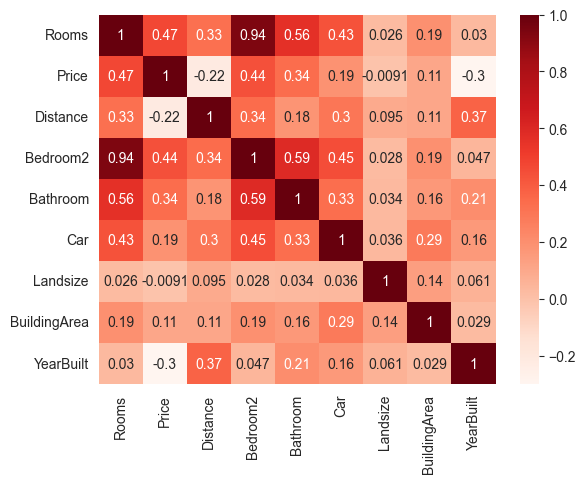

```python
# Spalten ohne kategorische Variablen und ohne Datum
data_heatmap = data_reduced_knn.drop(data_reduced_knn[['Suburb', 'Date', 'Type']], axis=1)
corr = data_heatmap.corr()
sns.heatmap(corr,
            xticklabels=corr.columns.values,
            yticklabels=corr.columns.values,
            annot=True, cmap=plt.cm.Reds)
plt.show()
```

Die Korrelationsmatrix zeigt, dass die variablen Rooms und Bedroom2 sehr stark korrelieren. Auf unsere Zielvariable Price hat die Variable Rooms den grösseren Einfluss mit einer Korrelation von 0.47. Dies ist nicht wirklich hoch und für einen gute Fit in der linearen Regression zu tief. Weiter erkennt man gut die Korrelation zwischen Rooms, Bedroom2 und Bathroom, was grundsätzlich logisch ist. Einen leichten Trend ist bei den beiden Variablen Price und YearBuilt zu erkennen. Dieser ist aber nicht sehr stark ausgeprägt. Weiter ist ein leichter Trend beim Preis und der Distanz zu sehen. Auch dieser Trend ist sehr leicht. Beide Trends sind wieder logisch nachvollziehbar, was bedeutet, dass ein älteres Haus günstiger ist oder auch für ein Objekt, welches weiter weg von der Innenstadt ist, weniger bezahlt wird.

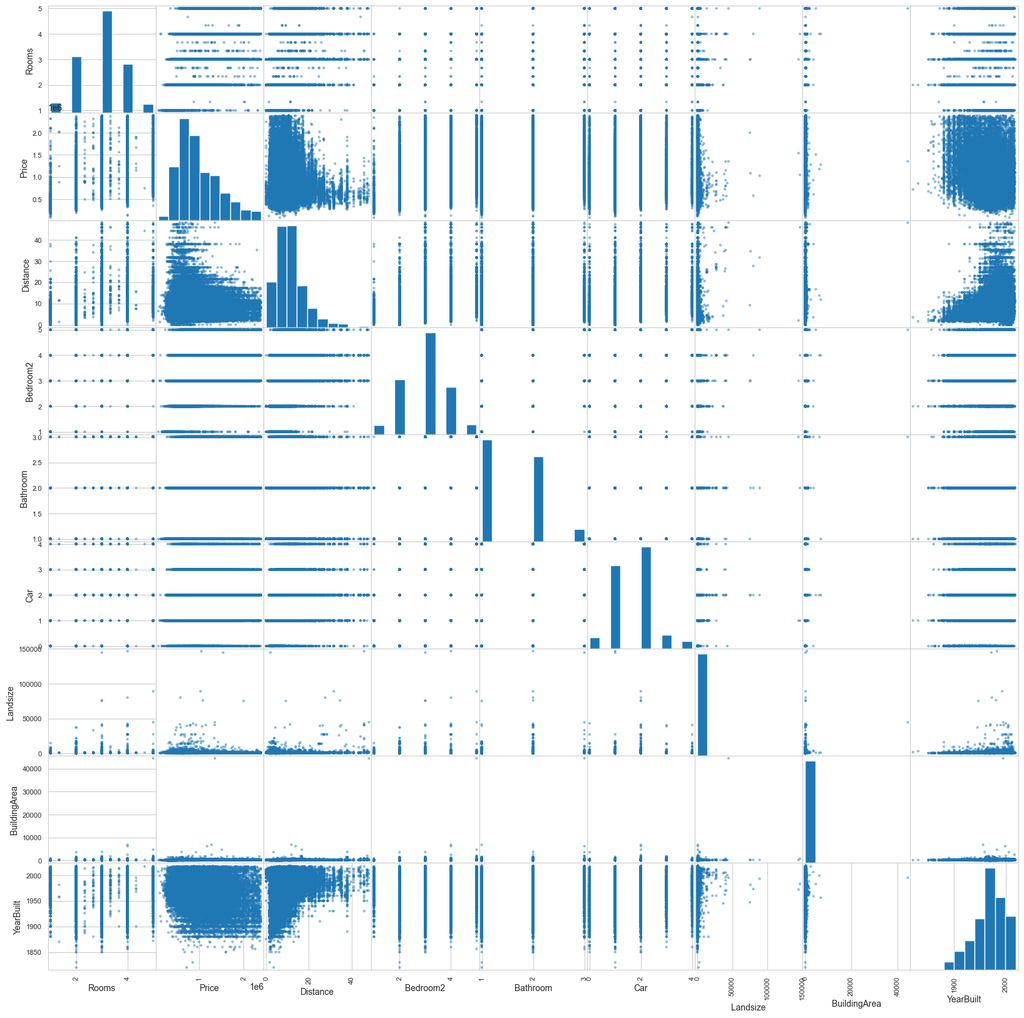

```python
scatter_matrix(data_heatmap, figsize=(20, 20))
plt.show()
```

Bei der Scattermatrix sind keine Korrelationen ersichtlich. Nun wird versucht, die Korrelationen mit der Zielvariable Price und der Distanz zu visualisieren.

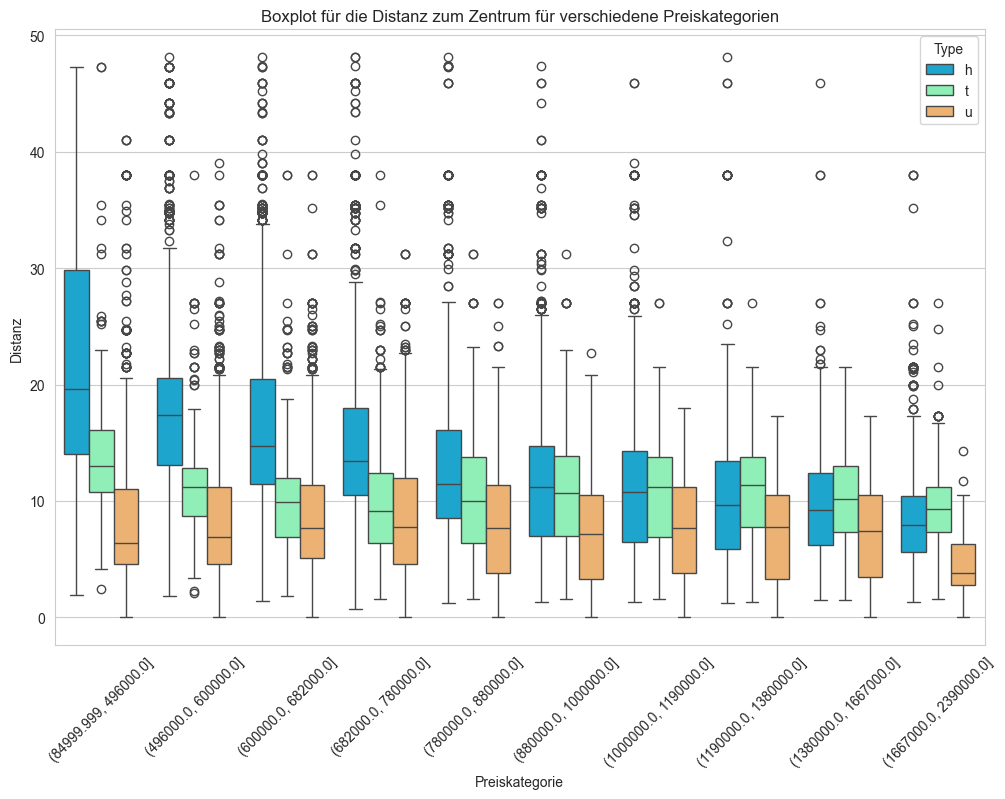

```python
data_reduced_knn = data_reduced_knn.copy()
data_reduced_knn['Price Category'] = pd.qcut(data_reduced_knn['Price'], q=10)
plt.figure(figsize=(12, 8))
sns.boxplot(x='Price Category', y='Distance', data=data_reduced_knn, palette='rainbow', hue='Type')
plt.xticks(rotation=45)
plt.title('Boxplot für die Distanz zum Zentrum für verschiedene Preiskategorien')
plt.xlabel('Preiskategorie')
plt.ylabel('Distanz')
plt.show()
```

Nun wollen wir schauen, ob das Baujahr einen Einfluss auf den Preis hat.

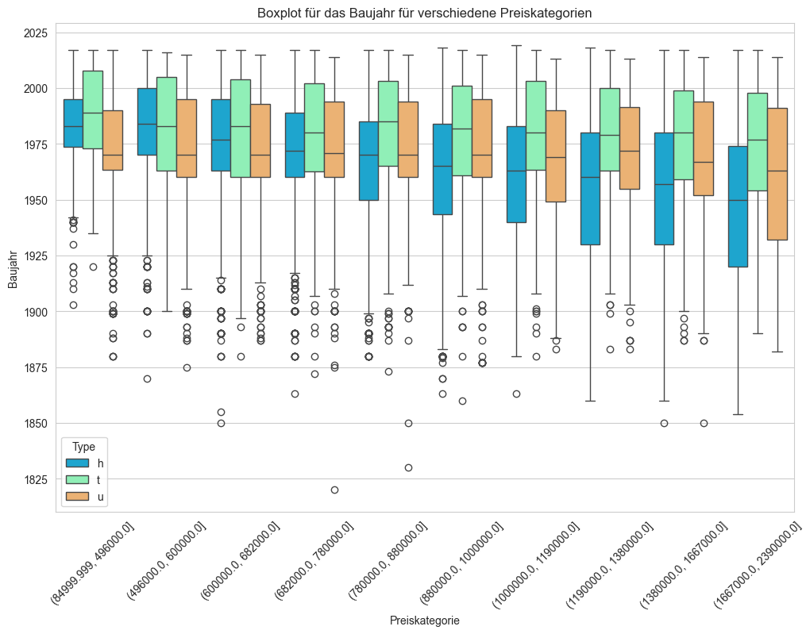

```python
# data_reduced_knn.loc[data_reduced_knn.index, 'Price Category'] = pd.qcut(data_reduced_knn['Price'], q=10)
plt.figure(figsize=(12, 8))
sns.boxplot(x='Price Category', y='YearBuilt', data=data_reduced_knn, palette='rainbow', hue='Type')
plt.xticks(rotation=45)
plt.title('Boxplot für das Baujahr für verschiedene Preiskategorien')
plt.xlabel('Preiskategorie')
plt.ylabel('Baujahr')
plt.show()
```

Wenn man hier auf den Median schaut, dann ist ein Trend zu alten Häusern zu erkennen. Dies ist doch eher erstaunlich und so, wie ich es nicht erwartet hätte.

## 5. Preprocessing

```python
def preprocessing(path, categorical_columns=['Type', 'Suburb'],
                  drop_columns=['Method', 'SellerG', 'Address', 'CouncilArea',
                                'Postcode', 'Regionname', 'Propertycount'],
                  drop_outliers=True, threshold=0.01, impute=True, impute_strategy='knn',
                  n_neighbors=3, fillna=False, fillna_strategy=0, dropna=True,
                  date_columns=['Date']):

    data = pd.read_csv(path)
    data = data.drop(drop_columns, axis=1)

    # Set data types for categorical variables and handle missing values
    for col in categorical_columns:
        if col in data.columns:
            data[col] = pd.Categorical(data[col])
            if fillna:
                data[col] = data[col].fillna('Andere')
            if drop_outliers:
                freq = data[col].value_counts(normalize=True)
                rare_categories = freq[freq < threshold].index
                data = data[~data[col].isin(rare_categories)]


    # Convert date columns to datetime
    for col in date_columns:
        if col in data.columns:
            data[col] = pd.to_datetime(data[col], format='%d/%m/%Y')

    numerical_cols = data.select_dtypes(include=['number']).columns
    for col in numerical_cols:
        if fillna:
            data[col] = data[col].fillna(fillna_strategy)
        if drop_outliers:
            Q1 = data[col].quantile(0.25)
            Q3 = data[col].quantile(0.75)
            IQR = Q3 - Q1
            data = data[(data[col] >= (Q1 - 1.5 * IQR)) & (data[col] <= (Q3 + 1.5 * IQR))]

    # Imputation
    if impute:
        # numerical_cols = data.select_dtypes(include=['number']).columns
        if impute_strategy == 'knn':
            imputer = KNNImputer(n_neighbors=n_neighbors)
            data[numerical_cols] = pd.DataFrame(imputer.fit_transform(data[numerical_cols]), columns=numerical_cols)
        if impute_strategy == 'mean':
            data[numerical_cols] = data[numerical_cols].fillna(data[numerical_cols].mean())

    # Handle missing values
    if dropna:
        data = data.dropna()

    return data
```

```python
preprocessing('Melbourne_Housing.csv')
```

|  | Suburb | Rooms | Type | Price | Date | Distance | Bedroom2 | Bathroom | Car | Landsize | BuildingArea | YearBuilt | Lattitude | Longtitude |
| --- | --- | --- | --- | --- | --- | --- | --- | --- | --- | --- | --- | --- | --- | --- |
| 1010 | Balwyn North | 2.0 | t | 450000.0 | 2016-09-03 | 2.6 | 2.0 | 1.0 | 1.0 | 0.0 | 66.0 | 2000.0 | -37.81730 | 144.99650 |
| 1011 | Balwyn North | 3.0 | h | 1074000.0 | 2016-09-03 | 2.6 | 3.0 | 1.0 | 0.0 | 245.0 | 140.0 | 1900.0 | -37.81380 | 144.99210 |
| 1017 | Balwyn North | 2.0 | h | 777500.0 | 2016-12-03 | 2.6 | 2.0 | 1.0 | 1.0 | 151.0 | 76.0 | 1900.0 | -37.81710 | 145.00900 |
| 1019 | Balwyn North | 3.0 | h | 760000.0 | 2016-12-03 | 2.6 | 3.0 | 2.0 | 1.0 | 0.0 | 120.0 | 2005.0 | -37.83310 | 144.99750 |
| 1020 | Balwyn North | 2.0 | h | 640000.0 | 2016-12-03 | 2.6 | 2.0 | 1.0 | 2.0 | 0.0 | 69.0 | 2000.0 | -37.81730 | 144.99650 |
| ... | ... | ... | ... | ... | ... | ... | ... | ... | ... | ... | ... | ... | ... | ... |
| 1891 | Brighton | 3.0 | h | 1000000.0 | 2016-08-22 | 8.4 | 3.0 | 1.0 | 1.0 | 353.0 | 112.0 | 1925.0 | -37.74064 | 145.00746 |
| 1903 | Brighton | 3.0 | t | 984000.0 | 2017-02-25 | 5.2 | 3.0 | 1.0 | 2.0 | 207.0 | 115.0 | 1910.0 | -37.76422 | 144.96888 |
| 1907 | Brighton | 4.0 | t | 1300000.0 | 2017-02-25 | 6.7 | 4.0 | 2.0 | 0.0 | 406.0 | 132.0 | 1930.0 | -37.74601 | 144.94799 |
| 1911 | Brighton | 2.0 | h | 502000.0 | 2016-07-26 | 7.5 | 2.0 | 1.0 | 1.0 | 105.0 | 63.0 | 1970.0 | -37.75557 | 144.91246 |
| 1918 | Brighton | 2.0 | u | 1040000.0 | 2016-11-27 | 8.4 | 2.0 | 1.0 | 2.0 | 209.0 | 93.0 | 1960.0 | -37.87291 | 145.04510 |

146 rows × 14 columns